# STA 305 HW 3

Jacky Guan

2023-10-03

Loading required libraries

```r
library(tidyverse)
library(openintro)
library(ggridges)
library(nycflights13)
knitr::opts_chunk$set(warning = FALSE, message = FALSE, fig.align = "center")
```

## 1. In-class Exercise for flights data set

### (a) filter - filter the data set and answer how many flights in the data set satisfy the given criteria.

#### • Find all flights that travel a distance of less than 200 miles.

```r
flights200 <- flights %>%
  filter(distance <= 200) %>%
  select(tailnum, dest, air_time) %>%
  arrange(desc(air_time))

tibble(flights200)
```

```
## # A tibble: 22,977 × 3
##    tailnum dest  air_time
##    <chr>   <chr>    <dbl>
##  1 N328JB  ACK        141
##  2 N37255  BOS        112
##  3 N967UW  BOS        107
##  4 N346JB  ACK         99
##  5 N284JB  BOS         99
##  6 N3FKAA  BOS         96
##  7 N76522  BOS         92
##  8 N346NB  BOS         91
##  9 N913XJ  BOS         86
## 10 N3DRAA  BOS         86
## # ℹ 22,967 more rows
```

```r
nrow(flights200)
```

```
## [1] 22977
```

#### • Find all flights that depart from JFK and land on ORD or CVG (Chicago or Dallas).

There were 3,323 flights that went from JFK to ORD or CVG, meaning that about 9 flights departed per day that went to either airport.

```r
chicago_or_dallas <- flights %>%
  filter(origin == "JFK", dest == "ORD" | dest == "CVG")

tibble (chicago_or_dallas)
```

```
## # A tibble: 3,323 × 19
##     year month   day dep_time sched_dep_time dep_delay arr_time sched_arr_time
##    <int> <int> <int>    <int>          <int>     <dbl>    <int>          <int>
##  1  2013     1     1      828            830        -2     1027           1012
##  2  2013     1     1     1546           1540         6     1753           1748
##  3  2013     1     1     1554           1600        -6     1830           1820
##  4  2013     1     1     1603           1550        13     1751           1739
##  5  2013     1     1     1714           1720        -6     1915           1915
##  6  2013     1     1     1910           1910         0     2126           2107
##  7  2013     1     1     2023           1945        38     2240           2206
##  8  2013     1     1     2115           1700       255     2330           1920
##  9  2013     1     2      817            820        -3     1015           1007
## 10  2013     1     2      828            830        -2     1021           1012
## # ℹ 3,313 more rows
## # ℹ 11 more variables: arr_delay <dbl>, carrier <chr>, flight <int>,
## #   tailnum <chr>, origin <chr>, dest <chr>, air_time <dbl>, distance <dbl>,
## #   hour <dbl>, minute <dbl>, time_hour <dttm>
```

```r
nrow(chicago_or_dallas)
```

```
## [1] 3323
```

```r
nrow(chicago_or_dallas) / 365
```

```
## [1] 9.10411
```

#### • Find all flights that flied a distance between 200 and 500 miles.

There are 62677 flights that flew between 200 and 500 miles in 2013.

```r
flights200_500 <- flights %>%
  filter(between(distance, 200, 500))

tibble(flights200_500)
```

```
## # A tibble: 62,677 × 19
##     year month   day dep_time sched_dep_time dep_delay arr_time sched_arr_time
##    <int> <int> <int>    <int>          <int>     <dbl>    <int>          <int>
##  1  2013     1     1      557            600        -3      709            723
##  2  2013     1     1      632            608        24      740            728
##  3  2013     1     1      645            647        -2      815            810
##  4  2013     1     1      732            735        -3      857            858
##  5  2013     1     1      733            736        -3      854            850
##  6  2013     1     1      800            810       -10      949            955
##  7  2013     1     1      801            805        -4      900            919
##  8  2013     1     1      805            815       -10     1006           1010
##  9  2013     1     1      817            810         7     1005            948
## 10  2013     1     1      821            825        -4      932            945
## # ℹ 62,667 more rows
## # ℹ 11 more variables: arr_delay <dbl>, carrier <chr>, flight <int>,
## #   tailnum <chr>, origin <chr>, dest <chr>, air_time <dbl>, distance <dbl>,
## #   hour <dbl>, minute <dbl>, time_hour <dttm>
```

```r
nrow(flights200_500)
```

```
## [1] 62677
```

#### • Find all flights that have a missing plane tail number. What is the percentage of flights with a missing plane tail number?

There are 2,512 planes missing a tail number. This corresponds to about 0.7% of all flights. This might be due to some form of system outage perhaps caused by electromagnetic interference.

```r
missing_tail <- flights %>%
  filter(is.na(tailnum))

tibble(missing_tail)
```

```
## # A tibble: 2,512 × 19
##     year month   day dep_time sched_dep_time dep_delay arr_time sched_arr_time
##    <int> <int> <int>    <int>          <int>     <dbl>    <int>          <int>
##  1  2013     1     2       NA           1545        NA       NA           1910
##  2  2013     1     2       NA           1601        NA       NA           1735
##  3  2013     1     3       NA            857        NA       NA           1209
##  4  2013     1     3       NA            645        NA       NA            952
##  5  2013     1     4       NA            845        NA       NA           1015
##  6  2013     1     4       NA           1830        NA       NA           2044
##  7  2013     1     5       NA            840        NA       NA           1001
##  8  2013     1     7       NA            820        NA       NA            958
##  9  2013     1     8       NA           1645        NA       NA           1838
## 10  2013     1     9       NA            755        NA       NA           1012
## # ℹ 2,502 more rows
## # ℹ 11 more variables: arr_delay <dbl>, carrier <chr>, flight <int>,
## #   tailnum <chr>, origin <chr>, dest <chr>, air_time <dbl>, distance <dbl>,
## #   hour <dbl>, minute <dbl>, time_hour <dttm>
```

```r
nrow(missing_tail)
```

```
## [1] 2512
```

```r
perc_missing_tail <- nrow(missing_tail) * 100 / nrow(flights)
print(paste0(perc_missing_tail, "%"))
```

```
## [1] "0.745896382165%"
```

### (b) select and rename

#### • Reorder the columns of flights such that origin, destination, travel distance, and air time are placed in the first four columns.

Rename the travel distance column to be “travel_distance” (this question was not originally included in class exercise).

```r
select_and_rename <- flights %>%
  mutate(distance, travel_distance = distance) %>%
  select(origin, dest, travel_distance, air_time, everything())

tibble(select_and_rename)
```

```
## # A tibble: 336,776 × 20
##    origin dest  travel_distance air_time  year month   day dep_time
##    <chr>  <chr>           <dbl>    <dbl> <int> <int> <int>    <int>
##  1 EWR    IAH              1400      227  2013     1     1      517
##  2 LGA    IAH              1416      227  2013     1     1      533
##  3 JFK    MIA              1089      160  2013     1     1      542
##  4 JFK    BQN              1576      183  2013     1     1      544
##  5 LGA    ATL               762      116  2013     1     1      554
##  6 EWR    ORD               719      150  2013     1     1      554
##  7 EWR    FLL              1065      158  2013     1     1      555
##  8 LGA    IAD               229       53  2013     1     1      557
##  9 JFK    MCO               944      140  2013     1     1      557
## 10 LGA    ORD               733      138  2013     1     1      558
## # ℹ 336,766 more rows
## # ℹ 12 more variables: sched_dep_time <int>, dep_delay <dbl>, arr_time <int>,
## #   sched_arr_time <int>, arr_delay <dbl>, carrier <chr>, flight <int>,
## #   tailnum <chr>, distance <dbl>, hour <dbl>, minute <dbl>, time_hour <dttm>
```

### (c) arrange

#### • What was the longest travel distance for any flight in our data set? What was the origin and the destination?

The longest flights were from `JFK` to `HNL`.

```r
longest_flight <- flights %>%
  arrange(desc(distance))

tibble(longest_flight)
```

```
## # A tibble: 336,776 × 19
##     year month   day dep_time sched_dep_time dep_delay arr_time sched_arr_time
##    <int> <int> <int>    <int>          <int>     <dbl>    <int>          <int>
##  1  2013     1     1      857            900        -3     1516           1530
##  2  2013     1     2      909            900         9     1525           1530
##  3  2013     1     3      914            900        14     1504           1530
##  4  2013     1     4      900            900         0     1516           1530
##  5  2013     1     5      858            900        -2     1519           1530
##  6  2013     1     6     1019            900        79     1558           1530
##  7  2013     1     7     1042            900       102     1620           1530
##  8  2013     1     8      901            900         1     1504           1530
##  9  2013     1     9      641            900      1301     1242           1530
## 10  2013     1    10      859            900        -1     1449           1530
## # ℹ 336,766 more rows
## # ℹ 11 more variables: arr_delay <dbl>, carrier <chr>, flight <int>,
## #   tailnum <chr>, origin <chr>, dest <chr>, air_time <dbl>, distance <dbl>,
## #   hour <dbl>, minute <dbl>, time_hour <dttm>
```

What is the full expression for `HNL`? It is Honolulu International Airport.

```r
filter(airports, faa == "HNL")
```

```
## # A tibble: 1 × 8
##   faa   name            lat   lon   alt    tz dst   tzone
##   <chr> <chr>         <dbl> <dbl> <dbl> <dbl> <chr> <chr>
## 1 HNL   Honolulu Intl  21.3 -158.    13   -10 N     Pacific/Honolulu
```

#### • What was the shortest air time for any flight (that actually finished the trip) in our data set? What was the origin and the destination?

The shortest flight only lasted for 20 minutes and flew from Newark International airport to `BDL`, which stands for Bradley International Airport.

```r
shortest_flight <- flights %>%
  filter(!is.na(air_time)) %>%
  arrange(air_time)

tibble(shortest_flight)
```

```
## # A tibble: 327,346 × 19
##     year month   day dep_time sched_dep_time dep_delay arr_time sched_arr_time
##    <int> <int> <int>    <int>          <int>     <dbl>    <int>          <int>
##  1  2013     1    16     1355           1315        40     1442           1411
##  2  2013     4    13      537            527        10      622            628
##  3  2013    12     6      922            851        31     1021            954
##  4  2013     2     3     2153           2129        24     2247           2224
##  5  2013     2     5     1303           1315       -12     1342           1411
##  6  2013     2    12     2123           2130        -7     2211           2225
##  7  2013     3     2     1450           1500       -10     1547           1608
##  8  2013     3     8     2026           1935        51     2131           2056
##  9  2013     3    18     1456           1329        87     1533           1426
## 10  2013     3    19     2226           2145        41     2305           2246
## # ℹ 327,336 more rows
## # ℹ 11 more variables: arr_delay <dbl>, carrier <chr>, flight <int>,
## #   tailnum <chr>, origin <chr>, dest <chr>, air_time <dbl>, distance <dbl>,
## #   hour <dbl>, minute <dbl>, time_hour <dttm>
```

```r
filter(airports, faa == "BDL")
```

```
## # A tibble: 1 × 8
##   faa   name           lat   lon   alt    tz dst   tzone
##   <chr> <chr>        <dbl> <dbl> <dbl> <dbl> <chr> <chr>
## 1 BDL   Bradley Intl  41.9 -72.7   173    -5 A     America/New_York
```

### (d) mutate

#### • Find the flight with the highest average speed. What is its destination?

It looks like a flight going from LaGuardia International airport flying all the way to Hartsfield Jackson Atlanta International Airport was in quite the hurry. The plane had an average speed of 703 miles/hour, which is already faster than the speed of sound. I hope there is some sort of measurement mistake here. The more I read about it, the less normal this seems to me.

```r
average_speed <- flights %>%
  mutate(speed = distance/air_time*60) %>%
  arrange(desc(speed))

tibble(average_speed)
```

```
## # A tibble: 336,776 × 20
##     year month   day dep_time sched_dep_time dep_delay arr_time sched_arr_time
##    <int> <int> <int>    <int>          <int>     <dbl>    <int>          <int>
##  1  2013     5    25     1709           1700         9     1923           1937
##  2  2013     7     2     1558           1513        45     1745           1719
##  3  2013     5    13     2040           2025        15     2225           2226
##  4  2013     3    23     1914           1910         4     2045           2043
##  5  2013     1    12     1559           1600        -1     1849           1917
##  6  2013    11    17      650            655        -5     1059           1150
##  7  2013     2    21     2355           2358        -3      412            438
##  8  2013    11    17      759            800        -1     1212           1255
##  9  2013    11    16     2003           1925        38       17             36
## 10  2013    11    16     2349           2359       -10      402            440
## # ℹ 336,766 more rows
## # ℹ 12 more variables: arr_delay <dbl>, carrier <chr>, flight <int>,
## #   tailnum <chr>, origin <chr>, dest <chr>, air_time <dbl>, distance <dbl>,
## #   hour <dbl>, minute <dbl>, time_hour <dttm>, speed <dbl>
```

```r
filter(airports, faa == "ATL")
```

```
## # A tibble: 1 × 8
##   faa   name                              lat   lon   alt    tz dst   tzone
##   <chr> <chr>                           <dbl> <dbl> <dbl> <dbl> <chr> <chr>
## 1 ATL   Hartsfield Jackson Atlanta Intl  33.6 -84.4  1026    -5 A     America/N…
```

#### • For diamonds data, create a new variable named carat_group, which groups data by less than 1 carat, 1-2 carat, 2-3 carat and greater than 3 carat.

It seems that most diamonds found are less than 1 carat.

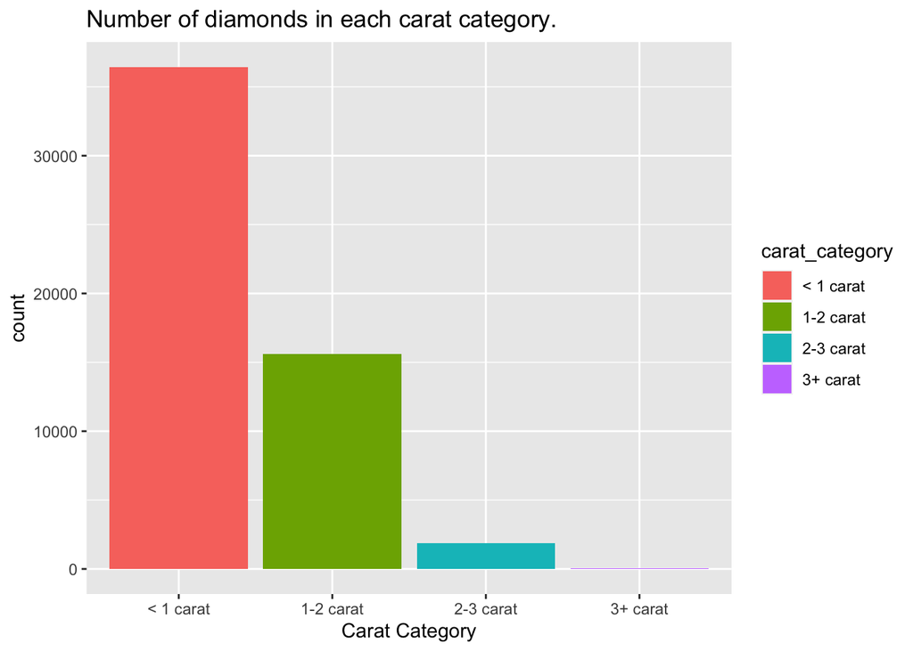

```r
diamond_carat_group <- diamonds %>%
  mutate(carat_category = case_when(
    between(carat, 0, 1) ~ "< 1 carat",
    between(carat, 1, 2) ~ "1-2 carat",
    between(carat, 2, 3) ~ "2-3 carat",
    between(carat, 3, 9) ~ "3+ carat",
    .default = NA
  ))

ggplot(diamond_carat_group) +
  geom_bar(aes(x = carat_category, fill = carat_category)) +
  labs(x = "Carat Category",
       title = "Number of diamonds in each carat category.")
```

### (e) group_by and summarize

#### • Find which airport around NYC had the worst delay on average.

The data is telling us that Newark has the worst delays averaging at around 15 minutes. JFK comes at a close second with 12 minutes on average while LaGuardia is doing well with only an average of 10 minutes of delay per flight.

```r
worst_delay <- flights %>%
  group_by(origin) %>%
  summarize(delay = mean(dep_delay, na.rm = TRUE))

tibble(worst_delay)
```

```
## # A tibble: 3 × 2
##   origin delay
##   <chr>  <dbl>
## 1 EWR     15.1
## 2 JFK     12.1
## 3 LGA     10.3
```

#### • Find which airport around NYC had the worst average delay on December 24, 2013.

On Christmas Eve 2013, Newark still managed to have the worst delays.

```r
worst_delay_christmas <- flights %>%
  filter(month == 12, day == 24) %>%
  group_by(origin) %>%
  summarize(delay = mean(dep_delay, na.rm = TRUE))

tibble(worst_delay_christmas)
```

```
## # A tibble: 3 × 2
##   origin delay
##   <chr>  <dbl>
## 1 EWR     9.45
## 2 JFK     6.09
## 3 LGA     4.54
```

#### • Find which origin has the most destinations?

It looks like Newark International Airport has the most destinations out of the three that are in the city.

```r
destinations <- flights %>%
  group_by(origin) %>%
  summarize(n_dest = dest[!duplicated(dest)])

tibble(destinations)
```

```
## # A tibble: 224 × 2
##    origin n_dest
##    <chr>  <chr>
##  1 EWR    IAH
##  2 EWR    ORD
##  3 EWR    FLL
##  4 EWR    SFO
##  5 EWR    LAS
##  6 EWR    PBI
##  7 EWR    MIA
##  8 EWR    ATL
##  9 EWR    PHX
## 10 EWR    MSP
## # ℹ 214 more rows
```

```r
jfk <- sum(destinations$origin == "JFK")
ewr <- sum(destinations$origin == "EWR")
lga <- sum(destinations$origin == "LGA")

most_dest <- data.frame(
  origin = c("JFK", "EWR", "LGA"),
  airports = c(jfk, ewr, lga)
)

tibble(most_dest)
```

```
## # A tibble: 3 × 2
##   origin airports
##   <chr>     <int>
## 1 JFK          70
## 2 EWR          86
## 3 LGA          68
```

## 2. Data Transformation and Visualization with the flights data set

Working with the data set flights in the package nycflights13, answer the following questions by performing necessary data transformation/visualization.

### (a) Create a histogram of arrival delays (excluding NAs) for all flights in June and July. Comment on your findings.

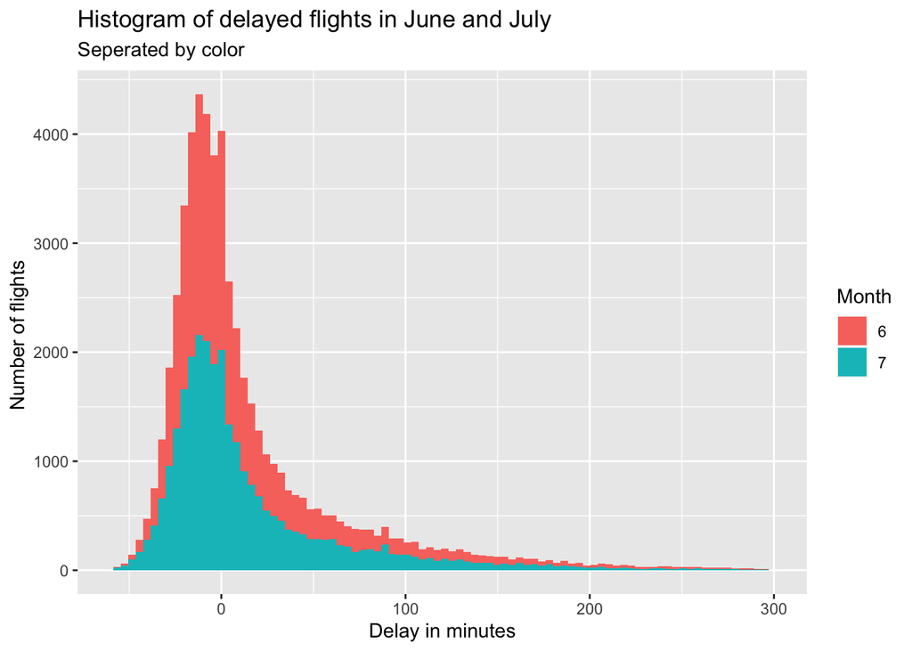

```r
arrival_delays <- flights %>%
  filter(between(month, 6, 7))

ggplot(arrival_delays) +
  geom_histogram(aes(x = arr_delay, fill = as.factor(month)), bins = 90) +
  xlim(-60, 300) +
  labs(x = "Delay in minutes", y = "Number of flights ",
       title = "Histogram of delayed flights in June and July",
       subtitle = "Seperated by color",
       fill = "Month")
```

### (b) Create a smooth line graph of arrival delays vs departure delays for all flights departing from EWR on the first day of each month. Comment on your findings.

For most months, it seems that arrival and departure delays are linearly related to each other. This is evident by the lines running throuhg each graph. It is no surprise that the number of delays increases during the months of July and August due to those months being the high seasons.

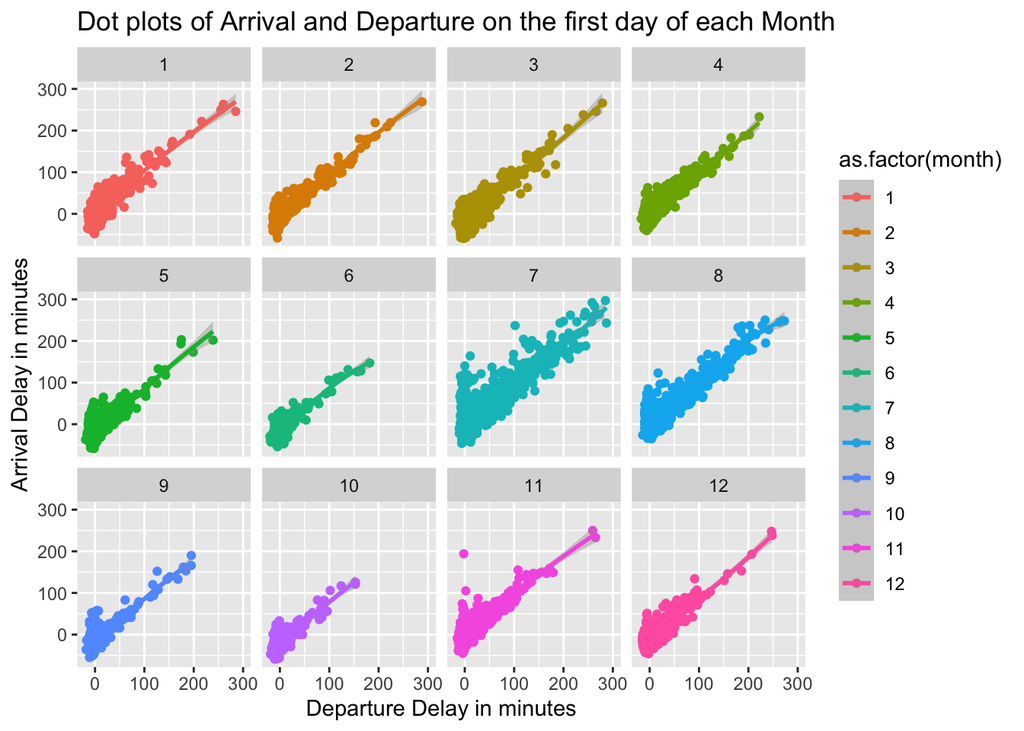

```r
first_day_delays <- flights %>%
  filter(day == 1)

ggplot(first_day_delays, aes(x = dep_delay,
  y = arr_delay, color = as.factor(month))) +
  geom_point() +
  geom_smooth() +
  xlim(-20, 300) +
  ylim(-60, 300) +
  facet_wrap(~ month) +
  labs(x = "Departure Delay in minutes", y = "Arrival Delay in minutes",
       title = "Dot plots of Arrival and Departure on the first day of each Month",
       fill = "Month")
```

### (c) Find the flights that actually departed with the shortest travel distance. What is its origin and destination airport?

From this graph, it seems that the shortest flight out of NYC by travel distance is headed towards Philadelphia. The flights take about 30 minutes on average and leave from both JFK and Newark

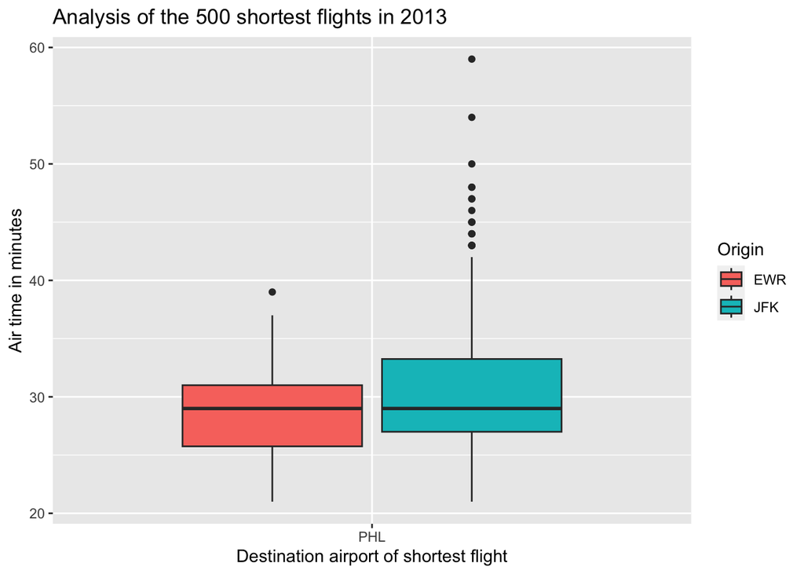

```r
shortest_distance <- flights %>%
  select(origin, dest, distance, air_time) %>%
  arrange(distance) %>%
  filter(!is.na(air_time))

shortest_distance  <- shortest_distance[1:500, ]

ggplot(shortest_distance) +
  geom_boxplot(aes(x = dest, y = air_time, fill = origin)) +
  labs(x = "Destination airport of shortest flight", y = "Air time in minutes",
       title = "Analysis of the 500 shortest flights in 2013",
       fill = "Origin")
```

### (d) Create a new categorical variable with two labels. Flights with a travel distance shorter than 500 miles are marked as “short-distance”, and otherwise “long-distance”. Create a bar plot to compare the number of flights in each category.

It seems that when comparing short- and long-distance flights, there are about 3x more long-distance flights compared with short distance ones.

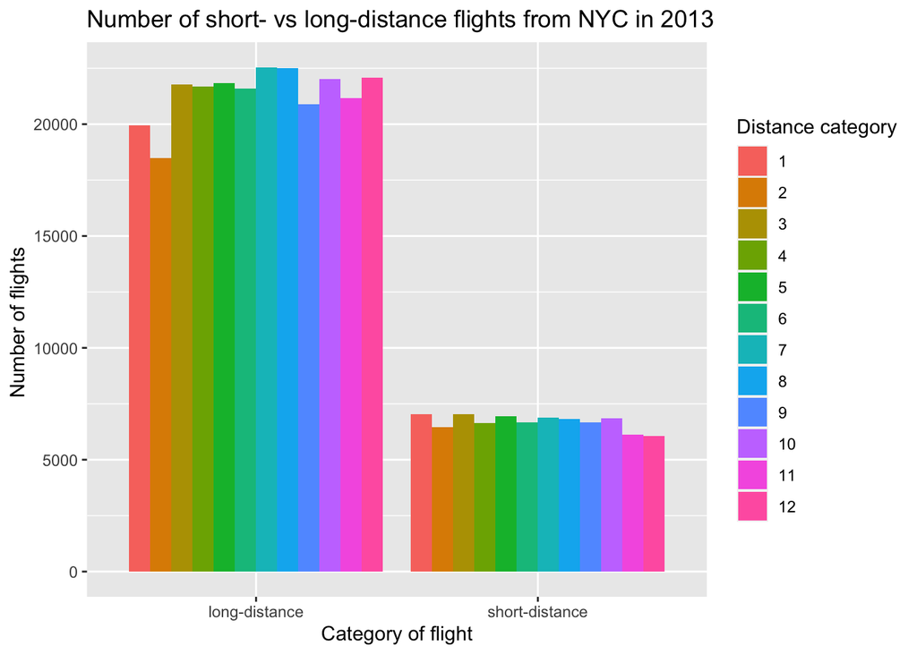

```r
short_vs_long <- flights %>%
  mutate(flight_distance_category = case_when(
    distance < 500 ~ "short-distance",
    distance >= 500 ~ "long-distance"
  ))

ggplot(short_vs_long, aes(x = flight_distance_category)) +
  geom_bar(position = "dodge", aes(fill = as.factor(month))) +
  labs(x = "Category of flight", y = "Number of flights ",
       title = "Number of short- vs long-distance flights from NYC in 2013",
       fill = "Distance category")
```

### (e) Find the destination airport that has the longest average departure delay by creating a graph.

It looks like `CAE` or Columbia Metropolitan Airport has the longest delays.

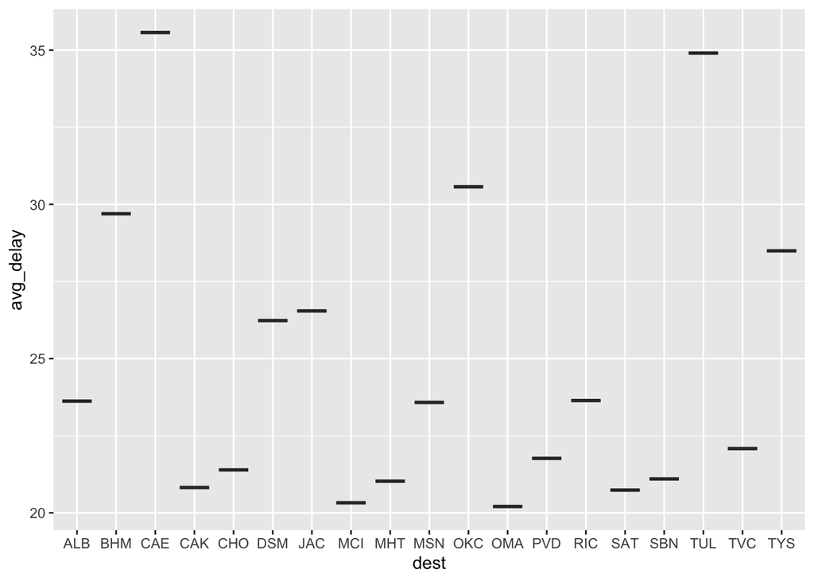

```r
longest_delay <- flights %>%
  group_by(dest) %>%
  select(dest, dep_delay) %>%
  mutate(avg_delay = mean(dep_delay, na.rm = TRUE)) %>%
  distinct(dest, .keep_all = TRUE) %>%
  arrange(desc(avg_delay)) %>%
  filter(avg_delay > 20)


ggplot(longest_delay) +
  geom_boxplot(aes(dest, avg_delay))
```

```r
filter(airports, faa == "CAE")
```

```
## # A tibble: 1 × 8
##   faa   name                    lat   lon   alt    tz dst   tzone
##   <chr> <chr>                 <dbl> <dbl> <dbl> <dbl> <chr> <chr>
## 1 CAE   Columbia Metropolitan  33.9 -81.1   236    -5 A     America/New_York
```

### (f) Answer the question in (d) without creating a graph.

It looks like `CAE` or Columbia Metropolitan Airport has the longest delays.

```r
longest_delay_1 <- flights %>%
  group_by(dest) %>%
  select(dest, dep_delay) %>%
  mutate(avg_delay = mean(dep_delay, na.rm = TRUE)) %>%
  distinct(dest, .keep_all = TRUE) %>%
  arrange(desc(avg_delay))

tibble(longest_delay_1[1:10, ])
```

```
## # A tibble: 10 × 3
##    dest  dep_delay avg_delay
##    <chr>     <dbl>     <dbl>
##  1 CAE          15      35.6
##  2 TUL          22      34.9
##  3 OKC          46      30.6
##  4 BHM          39      29.7
##  5 TYS          30      28.5
##  6 JAC          -3      26.5
##  7 DSM         109      26.2
##  8 RIC         115      23.6
##  9 ALB          -2      23.6
## 10 MSN          -4      23.6
```

### (g) Find the carriers with the highest and the lowest average flight speed for all their flights in the data set.

The fastest carrier is `HA` which stands for Hawaiian Airlines. This is understandable as they have the longest leg to fly.

The slowest carrier is `YV` which stands for Mesa Airlines. This airline does not seem to be a major airline and explains the leisurely pace at which the planes fly.

```r
avg_flight_speed <- flights %>%
  group_by(carrier) %>%
  mutate(speed = mean(distance / air_time * 60, na.rm = TRUE)) %>%
  distinct(dest, .keep_all = TRUE) %>%
  select(carrier, speed)

filter(avg_flight_speed, speed == max(avg_flight_speed$speed))
```

```
## # A tibble: 1 × 2
## # Groups:   carrier [1]
##   carrier speed
##   <chr>   <dbl>
## 1 HA       480.
```

```r
filter(avg_flight_speed, speed == min(avg_flight_speed$speed))
```

```
## # A tibble: 3 × 2
## # Groups:   carrier [1]
##   carrier speed
##   <chr>   <dbl>
## 1 YV       332.
## 2 YV       332.
## 3 YV       332.
```

```r
filter(airlines, carrier == "HA")
```

```
## # A tibble: 1 × 2
##   carrier name
##   <chr>   <chr>
## 1 HA      Hawaiian Airlines Inc.
```

```r
filter(airlines, carrier == "YV")
```

```
## # A tibble: 1 × 2
##   carrier name
##   <chr>   <chr>
## 1 YV      Mesa Airlines Inc.
```

### (h) (Bonus, not required) Find flights on which weekday (from Monday to Sunday) had the longest departure delay on average.

Done. Is there a better way to do this problem? I think I’m rather inefficient.

```r
longest_dep_weekday <- flights %>%
  mutate(day_of_week = weekdays(time_hour)) %>%
  mutate(flight_number = paste(carrier, as.character(flight))) %>%
  group_by(day_of_week, flight_number) %>%
  summarize(day_of_week, flight_number,
            avg_delay = mean(dep_delay, na.rm = TRUE)) %>%
  distinct(day_of_week, flight_number, .keep_all = TRUE)

days <- c("Monday", "Tuesday", "Wednesday", "Thursday", "Friday", "Saturday", "Sunday")

results <- list()

for (day in days) {
  result <- longest_dep_weekday %>%
    filter(day_of_week == day) %>%
    arrange(desc(avg_delay)) %>%
    head(1)
  results[[day]] <- result
}

for (day in days) {
  cat("For", day, ":", "\n")
  print(results[[day]])
  cat("\n")
}
```

```
## For Monday :
## # A tibble: 1 × 3
## # Groups:   day_of_week, flight_number [1]
##   day_of_week flight_number avg_delay
##   <chr>       <chr>             <dbl>
## 1 Monday      EV 5017             372
##
## For Tuesday :
## # A tibble: 1 × 3
## # Groups:   day_of_week, flight_number [1]
##   day_of_week flight_number avg_delay
##   <chr>       <chr>             <dbl>
## 1 Tuesday     YV 2693             387
##
## For Wednesday :
## # A tibble: 1 × 3
## # Groups:   day_of_week, flight_number [1]
##   day_of_week flight_number avg_delay
##   <chr>       <chr>             <dbl>
## 1 Wednesday   EV 3261             321
##
## For Thursday :
## # A tibble: 1 × 3
## # Groups:   day_of_week, flight_number [1]
##   day_of_week flight_number avg_delay
##   <chr>       <chr>             <dbl>
## 1 Thursday    DL 1223            426.
##
## For Friday :
## # A tibble: 1 × 3
## # Groups:   day_of_week, flight_number [1]
##   day_of_week flight_number avg_delay
##   <chr>       <chr>             <dbl>
## 1 Friday      UA 1105             307
##
## For Saturday :
## # A tibble: 1 × 3
## # Groups:   day_of_week, flight_number [1]
##   day_of_week flight_number avg_delay
##   <chr>       <chr>             <dbl>
## 1 Saturday    UA 545              299
##
## For Sunday :
## # A tibble: 1 × 3
## # Groups:   day_of_week, flight_number [1]
##   day_of_week flight_number avg_delay
##   <chr>       <chr>             <dbl>
## 1 Sunday      EV 4159             486
```

## 3. Analyzing the seattlepets data set

For the following questions, analyze the data set seattlepets in the package openintro. Read the help document and make sure that you understand the basic information about the data set before analysis.

### (a) How many species are there in the data set? What are they?

It looks like there are a lot of dogs and cats in seattle, but also goats and pigs..? There are 4 species in total.

```r
species_count <- seattlepets %>%
  group_by(species) %>%
  summarize(count = n())

species_count
```

```
## # A tibble: 4 × 2
##   species count
##   <chr>   <int>
## 1 Cat     17294
## 2 Dog     35181
## 3 Goat       38
## 4 Pig         6
```

### (b) What are the three most common pet names in Seattle?

According to the data provided, Lucy, Charlie, and Luna are the most common pet names in Seattle.

```r
pet_names <- seattlepets %>%
  group_by(animal_name) %>%
  filter(!is.na(animal_name)) %>%
  summarize(count = n()) %>%
  arrange(desc(count))

pet_names[1:3, ]
```

```
## # A tibble: 3 × 2
##   animal_name count
##   <chr>       <int>
## 1 Lucy          439
## 2 Charlie       387
## 3 Luna          355
```

### (c) What are the ten most common pet names for cats? What are the ten most common pet names for dogs? Write a code to print the result and their frequencies.

Names like Lucy, Luna, Charlie, etc. are all really popular names.

```r
common_names <- seattlepets %>%
  filter(!is.na(animal_name)) %>%
  group_by(animal_name, species) %>%
  summarize(count = n())

species <- c("Dog", "Cat")

count_table <- list()

for (i in species) {
  temp <- common_names %>%
    filter(species == i) %>%
    arrange(desc(count)) %>%
    head(10)
  count_table[[i]] <- temp
}

for (i in species) {
  cat("For", i, ":", "\n")
  print(count_table[[i]])
  cat("\n")
}
```

```
## For Dog :
## # A tibble: 10 × 3
## # Groups:   animal_name [10]
##    animal_name species count
##    <chr>       <chr>   <int>
##  1 Lucy        Dog       337
##  2 Charlie     Dog       306
##  3 Bella       Dog       249
##  4 Luna        Dog       244
##  5 Daisy       Dog       221
##  6 Cooper      Dog       189
##  7 Lola        Dog       187
##  8 Max         Dog       186
##  9 Molly       Dog       186
## 10 Stella      Dog       185
##
## For Cat :
## # A tibble: 10 × 3
## # Groups:   animal_name [10]
##    animal_name species count
##    <chr>       <chr>   <int>
##  1 Luna        Cat       111
##  2 Lucy        Cat       102
##  3 Lily        Cat        86
##  4 Max         Cat        83
##  5 Bella       Cat        82
##  6 Charlie     Cat        81
##  7 Oliver      Cat        73
##  8 Jack        Cat        65
##  9 Sophie      Cat        59
## 10 Leo         Cat        54
```

```r
count_table
```

```
## $Dog
## # A tibble: 10 × 3
## # Groups:   animal_name [10]
##    animal_name species count
##    <chr>       <chr>   <int>
##  1 Lucy        Dog       337
##  2 Charlie     Dog       306
##  3 Bella       Dog       249
##  4 Luna        Dog       244
##  5 Daisy       Dog       221
##  6 Cooper      Dog       189
##  7 Lola        Dog       187
##  8 Max         Dog       186
##  9 Molly       Dog       186
## 10 Stella      Dog       185
##
## $Cat
## # A tibble: 10 × 3
## # Groups:   animal_name [10]
##    animal_name species count
##    <chr>       <chr>   <int>
##  1 Luna        Cat       111
##  2 Lucy        Cat       102
##  3 Lily        Cat        86
##  4 Max         Cat        83
##  5 Bella       Cat        82
##  6 Charlie     Cat        81
##  7 Oliver      Cat        73
##  8 Jack        Cat        65
##  9 Sophie      Cat        59
## 10 Leo         Cat        54
```

### (d) How many names appear more than 100 times in the data set excluding “NA”?

There are 56 names that appear more than 100 times in the seattlepets dataset.

```r
names_freq <- seattlepets %>%
  group_by(animal_name) %>%
  summarize(count = n()) %>%
  arrange(desc(count)) %>%
  filter(count >= 100 & animal_name != "NA")

nrow(names_freq)
```

```
## [1] 56
```

### (e) For all names that appear more than 100 times in the data set, which has the highest “cat_to_dog” ratio? Which has the lowest? The “cat_to_dog” ratio can be computed this way - if a name appears 200 times, in which 150 are for cats and 50 are for dogs, the ratio is 150/50 = 3.

While Riley had the highest dog to cat ratio, Shadow had the highest cat to dog ratio.

This means that Riley is way more likely to be used for dogs (understandable because riley is somewhat of a wild name and suitable for dogs) while shadow is more likely to be used for cats.

```r
#create a dataframe with the count given the same species and name
count_species_name <- seattlepets %>%
  filter(!is.na(animal_name)) %>%
  group_by(animal_name, species) %>%
  summarize(count = n())

#copy the code from above to see the 100 most common pet names in seattle
names_freq <- seattlepets %>%
  group_by(animal_name) %>%
  summarize(count = n()) %>%
  arrange(desc(count)) %>%
  filter(count >= 100 & animal_name != "NA")

#initialize a list with 2 subdataframes (dog/cat) that will count the frequency of names for both types of animals
sep_species <- list()

#initialize a new dataframe called ratios where results will be funneled in for top 100 pets
ratio <- data.frame(
  Name <- character(),
  cat_to_dog <- numeric(),
  dog_to_cat <- numeric()
)

#add entries to sep_species list
for (i in c("Dog", "Cat")) {

#for each species in the dataframe, filter out the dataframe and add it to the sep_species dataframe
  sep_species[[i]] <- count_species_name %>%
    filter(species == i)
}

#make a another for loop that adds a new entry to the ratio dataframe for all the most popular pet names
for (name in names_freq$animal_name) {

    count_dog <- sep_species$Dog %>% filter(animal_name == name)
    count_cat <- sep_species$Cat %>% filter(animal_name == name)

    new_data <- data.frame(
        Name = name,
        cat_to_dog = (count_cat$count / count_dog$count),
        dog_to_cat = (count_dog$count / count_cat$count)
    )
    ratio <- rbind(ratio, new_data)
}

#filter out all the names
ratio <- ratio %>%
  arrange(cat_to_dog)

head(ratio, 1)
```

```
##    Name cat_to_dog dog_to_cat
## 1 Riley 0.07692308         13
```

```r
tail(ratio, 1)
```

```
##      Name cat_to_dog dog_to_cat
## 56 Shadow  0.6708861   1.490566
```